# A05_G48129884

# A

## 1.Use the first half of this dataset to be the training set and the second half of this dataset to be the test set. Your task is to predict the credit rating of an individual.

```r
dataset = read.csv("creditdata.csv")
str(dataset)
```

```
## 'data.frame':    4446 obs. of  14 variables:
##  $ rating    : Factor w/ 2 levels "bad","good": 2 2 1 2 2 2 2 2 2 1 ...
##  $ experience: int  9 17 10 0 0 1 29 9 0 0 ...
##  $ homeown   : Factor w/ 6 levels "ignore","other",..: 6 6 3 6 6 3 3 4 3 4 ...
##  $ loandurn  : int  60 60 36 60 36 60 60 12 60 48 ...
##  $ age       : int  30 58 46 24 26 36 44 27 32 41 ...
##  $ mstat     : Factor w/ 5 levels "divorced","married",..: 2 5 2 4 4 2 2 4 2 2 ...
##  $ rcds      : Factor w/ 2 levels "no_rec","yes_rec": 1 1 2 1 1 1 1 1 1 1 ...
##  $ jtype     : Factor w/ 4 levels "fixed","freelance",..: 2 1 2 1 1 1 1 1 2 4 ...
##  $ explvl    : int  73 48 90 63 46 75 75 35 90 90 ...
##  $ inc       : int  129 131 200 182 107 214 125 80 107 80 ...
##  $ assts     : int  0 0 3000 2500 0 3500 10000 0 15000 0 ...
##  $ debt      : int  0 0 0 0 0 0 0 0 0 0 ...
##  $ loanamount: int  800 1000 2000 900 310 650 1600 200 1200 1200 ...
##  $ purchprice: int  846 1658 2985 1325 910 1645 1800 1093 1957 1468 ...
```

```r
head(dataset)
```

```
##   rating experience homeown loandurn age   mstat    rcds     jtype explvl
## 1   good          9    rent       60  30 married  no_rec freelance     73
## 2   good         17    rent       60  58   widow  no_rec     fixed     48
## 3    bad         10   owner       36  46 married yes_rec freelance     90
## 4   good          0    rent       60  24  single  no_rec     fixed     63
## 5   good          0    rent       36  26  single  no_rec     fixed     46
## 6   good          1   owner       60  36 married  no_rec     fixed     75
##   inc assts debt loanamount purchprice
## 1 129     0    0        800        846
## 2 131     0    0       1000       1658
## 3 200  3000    0       2000       2985
## 4 182  2500    0        900       1325
## 5 107     0    0        310        910
## 6 214  3500    0        650       1645
```

```r
training_set = dataset[1:(4446/2),]
test_set = dataset[(4446/2+1):4446,]
```

## 2.Please ensure that the data are clean.

```r
sum(is.na(dataset))
```

```
## [1] 0
```

it is a clean dataset

## 3.Please provide the relevant exploratory and descriptive analysis.

```r
table(dataset$rating)
```

```
##
##  bad good
## 1249 3197
```

```r
table(dataset$homeown)
```

```
##
##  ignore   other   owner parents    priv    rent
##      20     319    2106     782     246     973
```

```r
table(dataset$mstat)
```

```
##
##  divorced   married separated    single     widow
##        38      3238       130       973        67
```

```r
table(dataset$rcds)
```

```
##
##  no_rec yes_rec
##    3677     769
```

```r
table(dataset$jtype)
```

```
##
##     fixed freelance    others   partime
##      2803      1021       171       451
```

```r
summary(dataset$experience)
```

```
##    Min. 1st Qu.  Median    Mean 3rd Qu.    Max.
##   0.000   2.000   5.000   7.991  12.000  48.000
```

```r
summary(dataset$loandurn)
```

```
##    Min. 1st Qu.  Median    Mean 3rd Qu.    Max.
##    6.00   36.00   48.00   46.45   60.00   72.00
```

```r
summary(dataset$age)
```

```
##    Min. 1st Qu.  Median    Mean 3rd Qu.    Max.
##   18.00   28.00   36.00   37.08   45.00   68.00
```

```r
summary(dataset$explvl)
```

```
##    Min. 1st Qu.  Median    Mean 3rd Qu.    Max.
##    35.0    35.0    51.0    55.6    72.0   180.0
```

```r
summary(dataset$inc)
```

```
##    Min. 1st Qu.  Median    Mean 3rd Qu.    Max.
##     1.0    90.0   124.0   140.6   170.0   959.0
```

```r
summary(dataset$assts)
```

```
##    Min. 1st Qu.  Median    Mean 3rd Qu.    Max.
##       0       0    3000    5355    6000  300000
```

```r
summary(dataset$loanamount)
```

```
##    Min. 1st Qu.  Median    Mean 3rd Qu.    Max.
##     100     700    1000    1039    1300    5000
```

```r
summary(dataset$purchprice)
```

```
##    Min. 1st Qu.  Median    Mean 3rd Qu.    Max.
##     105    1116    1400    1462    1692   11140
```

## 4.Please explain how this descriptive analysis informed your next steps.

it is unclear the way those independent variables influence the target variable. We should fit the data into classification model to determine their relationship.

# B

## 1.Please make a predictive model using logistic regression.

Fitting Logistic Regression to the Training set

```r
classifier.logistic = glm(formula = rating ~ .,
                 family = binomial,
                 data = training_set)
summary(classifier.logistic)
```

```
##
## Call:
## glm(formula = rating ~ ., family = binomial, data = training_set)
##
## Deviance Residuals:
##     Min       1Q   Median       3Q      Max
## -3.1915  -0.6031   0.3956   0.6973   2.5219
##
## Coefficients:
##                  Estimate Std. Error z value Pr(>|z|)
## (Intercept)    -2.738e-01  9.990e-01  -0.274 0.784032
## experience      7.646e-02  1.048e-02   7.293 3.03e-13 ***
## homeownother    3.322e-01  7.807e-01   0.425 0.670501
## homeownowner    1.733e+00  7.607e-01   2.278 0.022701 *
## homeownparents  1.404e+00  7.730e-01   1.816 0.069310 .
## homeownpriv     1.019e+00  7.911e-01   1.288 0.197857
## homeownrent     9.726e-01  7.646e-01   1.272 0.203349
## loandurn       -5.372e-03  4.882e-03  -1.100 0.271222
## age            -1.172e-02  6.999e-03  -1.675 0.094032 .
## mstatmarried    1.474e+00  5.415e-01   2.722 0.006481 **
## mstatseparated  1.728e-01  6.154e-01   0.281 0.778852
## mstatsingle     9.441e-01  5.443e-01   1.735 0.082814 .
## mstatwidow      1.976e+00  8.173e-01   2.417 0.015639 *
## rcdsyes_rec    -1.874e+00  1.539e-01 -12.176  < 2e-16 ***
## jtypefreelance -8.816e-01  1.429e-01  -6.168 6.93e-10 ***
## jtypeothers    -1.113e+00  3.032e-01  -3.671 0.000241 ***
## jtypepartime   -1.275e+00  1.813e-01  -7.034 2.00e-12 ***
## explvl         -1.271e-02  3.813e-03  -3.334 0.000855 ***
## inc             6.200e-03  8.841e-04   7.012 2.34e-12 ***
## assts           2.638e-05  9.123e-06   2.891 0.003834 **
## debt           -1.920e-04  4.640e-05  -4.138 3.50e-05 ***
## loanamount     -1.975e-03  2.468e-04  -8.002 1.23e-15 ***
## purchprice      1.022e-03  1.869e-04   5.467 4.57e-08 ***
## ---
## Signif. codes:  0 '***' 0.001 '**' 0.01 '*' 0.05 '.' 0.1 ' ' 1
##
## (Dispersion parameter for binomial family taken to be 1)
##
##     Null deviance: 2646.7  on 2222  degrees of freedom
## Residual deviance: 1954.8  on 2200  degrees of freedom
## AIC: 2000.8
##
## Number of Fisher Scoring iterations: 5
```

## 2.Which variables in the logistic regression model are significant or important?

### 3.Please make a predictive model using a decision tree

```r
library(rattle)
```

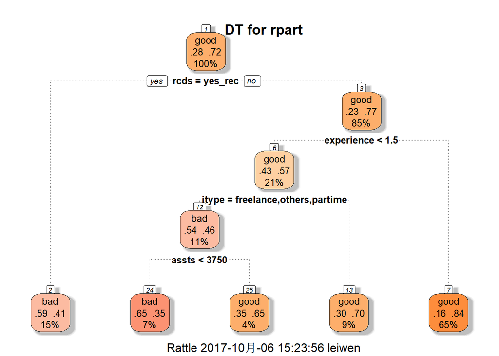

```r
library(rpart)
classifier.decision = rpart(formula = rating ~ .,
                   data = training_set)
classifier.decision.prune <- prune(classifier.decision, cp = 0.024)
fancyRpartPlot(classifier.decision.prune, main="DT for rpart",  palettes=c("Reds", "Oranges"))
```

### 4.Describe and explain the tree. How will you explain the tree to your client (less than 250words)?

According to the decision tree model, the potential borrower who has good credit has either those 3 attributes:

1.they have no record, job experience is less than 1.5, their jobs are not freelance nor others nor partime.

2.they have no record, job experience is less than 1.5, their jobs are freelance or others or partime, but their assets are more than 3750.

3.they have no record, job experience is more than 1.5.

According to the decision tree model, the potential borrower who has bad credit has either those 2 attributes:

1.they have no record, job experience is less than 1.5, their jobs are freelance or others or partime, but their assets are less than 3750

2.they have records

# C

## 1. Please help your client understand which model is better for predicting purposes.

### Making the Confusion Matrix of logistic regression

```r
y_prob.logisitc = predict(classifier.logistic,type = 'response', newdata = test_set[-1])## probability
y_pred.logisitc = ifelse(y_prob.logisitc > 0.5, 1, 0)
```

confusing matrix and accurancy of logistic regression

```r
cm = table(test_set[, 1], y_pred.logisitc)
cm
```

```
##       y_pred.logisitc
##           0    1
##   bad   329  292
##   good  171 1431
```

```r
accurancy.logisitc = (cm[1,1]+cm[2,2])/sum(cm)
print(paste('Accuracy of logistic regression:',accurancy.logisitc))
```

```
## [1] "Accuracy of logistic regression: 0.791722896986055"
```

### For decision tree

```r
y_prob.decisiontree = predict(classifier.decision.prune, newdata = test_set[-1])## probability
y_pred.decisiontree = predict(classifier.decision.prune, newdata = test_set[-1], type = 'class')
```

confusing matrix and accurancy of Decision tree

```r
cm = table(test_set[, 1], y_pred.decisiontree)
cm
```

```
##       y_pred.decisiontree
##         bad good
##   bad   331  290
##   good  276 1326
```

```r
accurancy.desciontree = (cm[1,1]+cm[2,2])/sum(cm)
print(paste('Accuracy of decision tree:',accurancy.desciontree))
```

```
## [1] "Accuracy of decision tree: 0.745389113810166"
```

Since the accuracy of test set of decision tree is less than that of logistic regression, logistic regression is a better model for predicting purposes

## 2. Find a way to explain sensitivity, specificity and auc in the ROC to your client (in less than 250 words).

```r
library(ROCR)
```

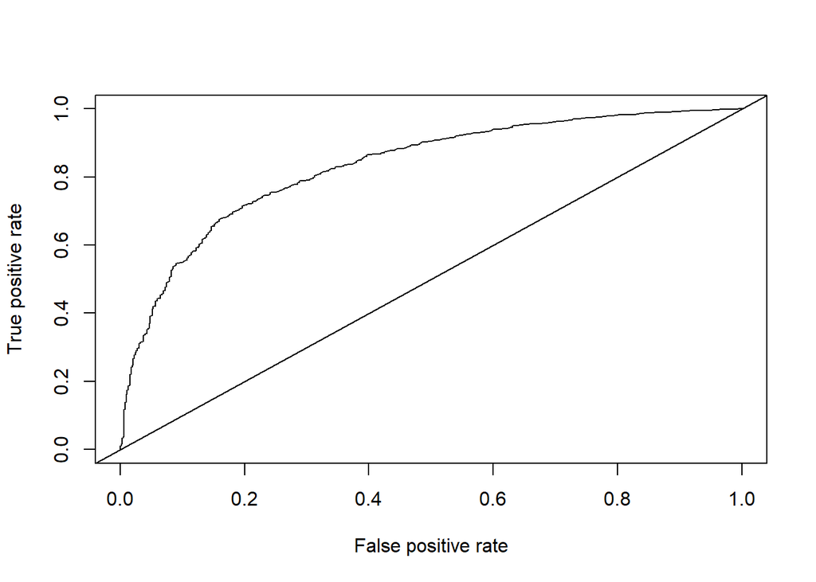

```r
pr <- prediction(y_prob.logisitc, test_set$rating)
prf <- performance(pr, measure = "tpr", x.measure = "fpr")
plot(prf) ##ROC curve
abline(a=0, b= 1)
```

```r
auc <- performance(pr, measure = "auc")
auc <- auc@y.values[[1]]
auc
```

```
## [1] 0.8305952
```

# ROC and AUC of decision tree

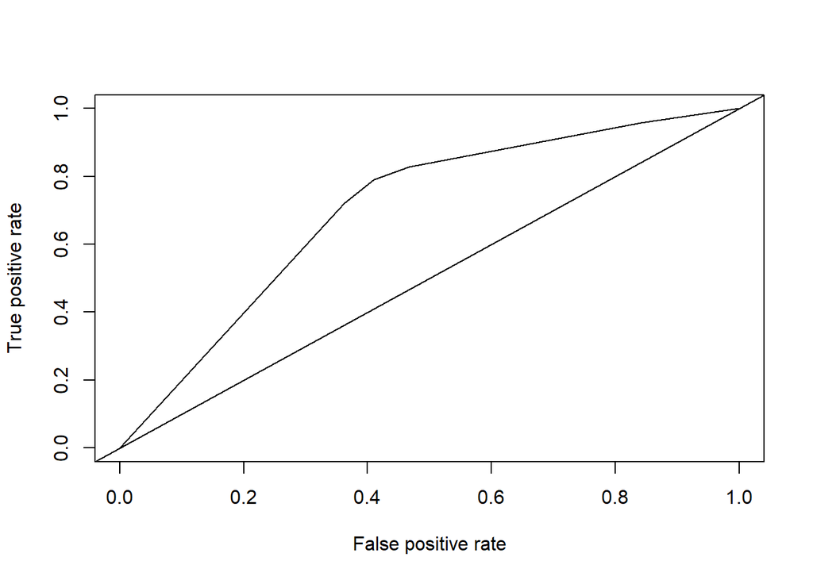

```r
library(ROCR)
pred <- prediction(y_prob.decisiontree[,2], test_set$rating)
perf <- performance(pred,"tpr","fpr")
plot(perf)
abline(a=0, b= 1)
```

```r
auc2 <- performance(pred, measure = "auc")
auc2 <- auc2@y.values[[1]]
print(auc2)
```

```
## [1] 0.7027201
```